# Electronic supplements for CARMMHA’s pelagic injury paper

# 1 Preamble

This is an Electronic Supplement to the manuscript Marques et al. “Quantifying Deepwater Horizon oil spill induced injury on pelagic cetaceans”.

The master file containing links to all supplementary files related to this paper is this Electronic Supplements master file.

If you make use of any of this material in your work, it would be appreciated if you would contact Tiago Marques to let him know.

# 2 Introduction

This document is a master file that presents a full list of Electronic Supplements available.

All these files are created as dynamic reports using RMarkdown.

The source .Rmd files are provided in the github repository:

https://github.com/TiagoAMarques/CARMMHApapersSI

The above repository also includes all the code required for readers to reproduce independently the paper results. Below is a quick description of how all the results in the paper might be recreated by the reader, within a framework of reproducible research.

This means also that it should be straightforward for a reader to update the results with new information, be it new data that becomes available or different assumptions about the populations, allowing to explore both the consequences of new knowledge or the impact of the assumptions we made on the results presented.

# 3 List of Electronic Supplements

Back to Introduction

# 4 How to reproduce the paper results

Back to Introduction

All the results in the paper can be recreated by the reader by running the code provided. Having the code also facilitates extending and using the code under different scenarios, species and locations. This is considered the most convenient way to share the results, since all the outputs would be too large to share in the github repository.

## 4.1 All the results

The results shown in the paper tables are produced by different bits of code from the supplementary material:

- Table 1 and 2 are produced within IniPopSizes.pdf; In fact, we recommend you run this first as it also creates a table (`Table4GetInjury.txt`) required to run the code in `GetInjury.pdf` that creates Table 3 below.
- Table 3 is produced within GetInjury.pdf. This can only be run after you have created the results. Note that it is fundamental that there is an object `ns` that defines in `GetInjury.Rmd` the correct number of iterations you used to run the code.

To produce the results in Table 3 the user would have to run the code chunk `getresults` (in file GetInjury.pdf) that runs the actual simulations. That chunk is set to not run by default when you compile GetInjury.pdf.

Running that code is safer to be done directly on a console. If you compile GetInjury.pdf after turning the argument `eval=FALSE` into `eval=TRUE` you will also get as a bonus the `GetInjury` document, which has summary tables of all the results.

This is also the code inside the file `RunAllSims.R`, that could be sourced to produce the same effect, and shown below for completeness:

```r
#this runs all the simulations and produces outputs for all species
source("Functions/reqfuns.R")         # most functions are here
source("Functions/SilerFuns.R")       # Siler model functions are here
source("Functions/runSims.R")         # To run the simulations for all species
#define the species we run simulations for
Sps <- c("Bwsp", "Fatt", "Ggri", "Gmac", "Kosp", "Pele", "Pmac", "Satt", "Sbre", "Scly", "Scoe", "Sfro", "Slon", "Ttro", "Ttrs","Ttru")
#define the number of iterations to run
ns <- 5
# define the number of years each iteration is run for
ny <- 150
for (i in Sps){
runSims(Sp = i, nsims = ns, nyears = ny)
}
```

The folder structure and all files required to successfully run the code is in the above github repository (under folder `FolderArchitecture2runCode`). The recommended procedure is to download this entire folder into a local folder and then run `RunAllSims.R`.

At a bare minimum running the code requires the following folders and the material provided in them:

- `InputFiles`: this folder includes a number of files that are treated as data, inputs required to run the code, including the key file `SpeciesDefinitionFile.xlsx` that contains all the details for all the different taxonomic units
- `InOutBySp`: a folder that also contains a specific set of subfolders with inputs per species, namely `N_boot.csv` and `N_boot_in_oil.csv`, a distribution of initial population sizes of both all animals and exposed animals. This is also the folder where results for each taxonomic unit are outputted into
- `Functions`: folder containing all the R code including functions required to run the simulations

Note that the chunk `getresults` (in file GetInjury.pdf) could take a considerable amount of time to run. The consequence of running said chunk will be to populate the folders inside `InOutBySp` with the R workspaces holding the results that the rest of the code in GetInjury.pdf uses to produce the tables with injury metrics.

## 4.2 A single taxonomic unit

If one wants to run a simulation for a single taxonomic unit it might be simpler to use simply the following code.

As an example, this would run a simulation for the sperm whale, for 50 years, with 3 iterations,

```r
#define species
sp <- "Pmac"
#define number of years
years <- 50
#define number of iterations
# Warning: starting with a small number of iterations is highly recommended.
sims <- 3
# this is also inside "RunAllSims.R"
source("Functions/reqfuns.R")         # most functions are here
source("Functions/SilerFuns.R")       # Siler model functions are here
source("Functions/runSims.R")         # function to run the simulations for all species
runSims(Sp = sp, nsims = sims, nyears = years)
```

This code will nonetheless require the corresponding taxonomic unit specific part of the above folder architecture to run smoothly.

# 5 References

Glennie, R.; Thomas, L.; Speakman, T.; Garrison, L.; Takeshita, R. & Schwacke, L. 2021. Estimating spatially-varying density and time-varying demographics with open population spatial capture-recapture: a photo-ID case study on bottlenose dolphins in Barataria Bay, Louisiana, USA [arXiv:2106.09579](https://arxiv.org/abs/2106.09579)

Roberts, J. J.; Best, B. D.; Mannocci, L.; Fujioka, E.; Halpin, P. N.; Palka, D. L.; Garrison, L. P.; Mullin, K. D.; Cole, T. V. N.; Khan, C. B.; McLellan, W. A.; Pabst, D. A. & Lockhart, G. G. 2016 Habitat-based cetacean density models for the U.S. Atlantic and Gulf of Mexico *Scientific Reports* **6**: 22615 DOI: [10.1038/srep22615](https://www.nature.com/articles/srep22615)

# 6 Reproducible research

We have invested a considerable amount of time to make our analysis reproducible. This means also that it should be relatively straightforward for a reader to update the results with new information, be it new data that becomes available or different assumptions about population, allowing to explore both the consequences of new knowledge or the impact of the assumptions we made on the results presented.

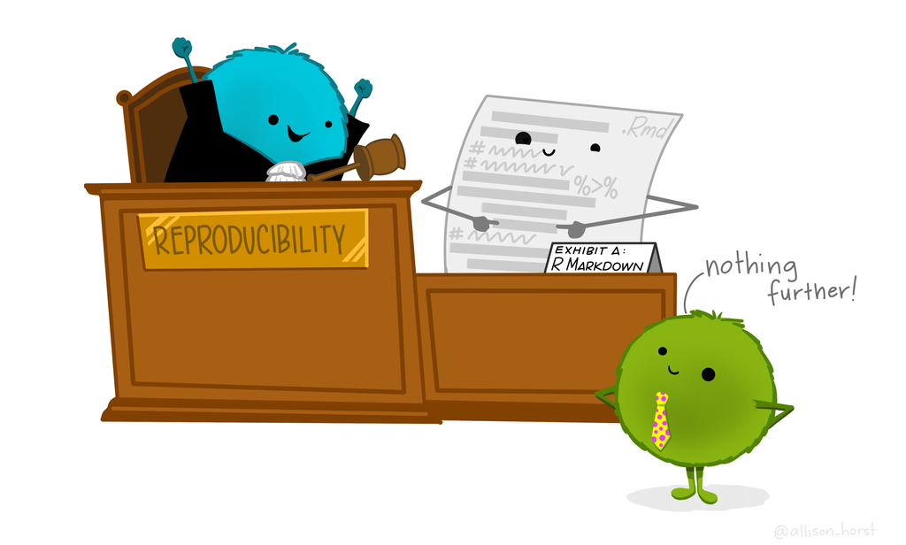

Artwork by @allison_horst at available at https://github.com/allisonhorst/stats-illustrations. This image illustrates the concept of reproducible research and is a tribute to Allison’s work on combining art and science.